# VaR - metoda symulacji historycznych + testy wsteczne

Andrii Morozov

30 01 2021

# **NIEZBEDNE FUNKCJE**

```r
df <- read.csv("S&P500.csv",sep = ",")

stopaPR <- function(.df){
  Volatility <- NULL
  for(i in 1:(nrow(.df)-1)){
    Volatility[i] <- ((.df$Adj.Close[i+1]-.df$Adj.Close[i])/(.df$Adj.Close[i]))*100
  }
  Volatility[nrow(.df)] <- NA
  .df <- cbind(.df, Volatility)
  return(.df)
}

stopaLN <- function(.df){
  VolatilityLN <- NULL
  for(i in 1:(nrow(.df)-1)){
    VolatilityLN[i] <- log(.df$Adj.Close[i+1]/.df$Adj.Close[i])*100
  }
  VolatilityLN[nrow(.df)] <- NA
  .df <- cbind(.df, VolatilityLN)
  return(.df)
}

mChristoffersen <- function(.vector,.VaR){
  a <- c(0,0,0,0)
  switch <- c(FALSE,FALSE,FALSE,FALSE)
  count <- 1
  repeat{
    if(count == 1){
      if(.vector[count] < .VaR){
        a[2] <- a[2] + 1
        switch[2] <- TRUE
        count <- count + 1
      }else{
        a[1] <- a[1] + 1
        switch[1] <- TRUE
        count <- count + 1
      }
    }else{
      if(.vector[count] < .VaR){
        if(match(TRUE, switch) == 2){
          a[4] <- a[4] + 1
          switch[match(TRUE, switch)] <- FALSE
          switch[4] <- TRUE
          count <- count + 1
        } else if(match(TRUE, switch) == 1){
          a[2] <- a[2] + 1
          switch[match(TRUE, switch)] <- FALSE
          switch[2] <- TRUE
          count <- count + 1
        } else if(match(TRUE, switch) == 3){
          a[4] <- a[4] + 1
          switch[match(TRUE, switch)] <- FALSE
          switch[4] <- TRUE
          count <- count + 1
        }else{
          a[4] <- a[4] + 1
          count <- count + 1
        }
      }else{
        if(match(TRUE, switch) == 4){
          a[3] <- a[3] + 1
          switch[match(TRUE, switch)] <- FALSE
          switch[3] <- TRUE
          count <- count + 1
        } else if(match(TRUE, switch) == 3){
          a[1] <- a[1] + 1
          switch[match(TRUE, switch)] <- FALSE
          switch[1] <- TRUE
          count <- count + 1
        } else if(match(TRUE, switch) == 2){
          switch[match(TRUE, switch)] <- FALSE
          switch[3] <- TRUE
          a[3] <- a[3] + 1
          count <- count + 1
        } else{
          a[1] <- a[1] + 1
          count <- count + 1
        }
      }
    }
    if(count > length(.vector)){
      break
    }
  }
  q0 <- ((a[1])/(a[1]+a[2]))
  q1 <- ((a[3])/(a[3]+a[4]))
  q <- ((a[1]+a[3])/(sum(a)))
  st <- ((q/q0)^a[1])*(((1-q)/(1-q0))^a[2])*((q/q1)^a[3])*(((1-q)/(1-q1))^a[4])
  final <- -2*log(st)
  return(final)
}

mKupiec <- function(.vector,.VaR){
  count <- 0
  for(i in 1:length(.vector)){
    if(.vector[i] < .VaR){
      count <- count + 1
    }
  }
  return(count)
}

mVaR <- function(.vector){
  N <- 250
  final2 <- NULL
  final5 <- NULL
  finalC2 <- NULL
  finalC5 <- NULL
  kupiec1 <- NULL
  kupiec5 <- NULL
  chris1 <- NULL
  chris5 <- NULL
  count <- 1
  repeat {
    tempVector <- sort(.vector[count:(count-1+N)],decreasing = FALSE)
    final2[count] <- tempVector[(0.01*N)]
    final5[count] <- tempVector[(0.05*N)]
    finalC2[count] <- mean(tempVector[1:(0.01*N)])
    finalC5[count] <- mean(tempVector[1:(0.05*N)])
    kupiec1[count] <- mKupiec(.vector[count:(count-1+N)],final2[count])
    kupiec5[count] <- mKupiec(.vector[count:(count-1+N)],final5[count])
    chris1[count] <- mChristoffersen(.vector[count:(count-1+N)],final2[count])
    chris5[count] <- mChristoffersen(.vector[count:(count-1+N)],final5[count])
    count <- count + 1
    if((count+N) == length(.vector)){
      break
    }
  }
  return(cbind(final2,final5,finalC2,finalC5,kupiec1,kupiec5,chris1,chris5))
}

VaRW <- function(.vector){
  N <- 250
  final2 <- NULL
  final5 <- NULL
  finalC2 <- NULL
  finalC5 <- NULL
  kupiec1 <- NULL
  kupiec5 <- NULL
  chris1 <- NULL
  chris5 <- NULL
  count <- 1
  q <- 0.96
  repeat {
    tempVector <- sort(.vector[count:(count-1+N)],decreasing = FALSE)
    temp <- rep(0,N)
    for(i in 1:N){
      if( i > 1){
        temp[i] <- temp[i-1]+((1-q)*q^(N-match(tempVector[i],.vector[count:(count-1+N)]))/(1-q^N))
      }else{
        temp[i] <- ((1-q)*q^(N-match(tempVector[i],.vector[count:(count-1+N)]))/(1-q^N))
      }
    }
    for(i in 1:length(temp)){
      if(temp[i]>=0.01){
        final2[count] <- tempVector[i]
        finalC2[count] <- mean(tempVector[1:match(final2[count],tempVector)])
        kupiec1[count] <- mKupiec(.vector[count:(count-1+N)],final2[count])
        chris1[count] <- mChristoffersen(.vector[count:(count-1+N)],final2[count])
        break
      }
    }
    for(i in 1:length(temp)){
      if(temp[i]>=0.05){
        final5[count] <- tempVector[i]
        finalC5[count] <- mean(tempVector[1:match(final5[count],tempVector)])
        kupiec5[count] <- mKupiec(.vector[count:(count-1+N)],final5[count])
        chris5[count] <- mChristoffersen(.vector[count:(count-1+N)],final5[count])
        break
      }
    }
    count <- count + 1
    if((count+N) == length(.vector)){
      break
    }
  }
  return(cbind(final2,final5,finalC2,finalC5,kupiec1,kupiec5,chris1,chris5))
}

EWMA <- function(.vector){
  weight <- 0.96
  N <- 250
  count <- 1
  final1 <- NULL
  final5 <- NULL
  ES99 <- NULL
  ES95 <- NULL
  kupiec1 <- NULL
  kupiec5 <- NULL
  chris1 <- NULL
  chris5 <- NULL
  repeat {
    tempVector <- .vector[count:(count-1+N)]
    temp <- rep(0,N)
    w <- rep(0,N)
    for(i in 1:N){
      temp[i] <- ((tempVector[i])^2)*(1-weight)*(weight^(i-1))
    }
    final1[count] <- -2.33*sqrt(sum(temp))
    final5[count] <- -1.64*sqrt(sum(temp))
    ES99[count] <- final1[count]*(exp(-(2.33^2)/2))/(sqrt(2*pi)*0.01)
    ES95[count] <- final5[count]*(exp(-(1.64^2)/2))/(sqrt(2*pi)*0.05)
    kupiec1[count] <- mKupiec(.vector[count:(count-1+N)],final1[count])
    kupiec5[count] <- mKupiec(.vector[count:(count-1+N)],final5[count])
    chris1[count] <- mChristoffersen(.vector[count:(count-1+N)],final1[count])
    chris5[count] <- mChristoffersen(.vector[count:(count-1+N)],final5[count])
    count <- count + 1
    if((count+N) == length(.vector)){
      break
    }
  }
  return(cbind(final1,final5,kupiec1,kupiec5,chris1,chris5,ES99,ES95))
}
```

# **WSTEP**

**Celem projektu** jest przeprowadzenie symulacji VaRow dla wybranego indeksu gieldowego roznymi metodami.

**Hipoteza badawcza**: Wyniki symulacji metoda: **historyczna prosta**, **historyczna z wagami** oraz **EWMA** nie roznia sie istotnie.

**Opis danych**

```
## 'data.frame':    7823 obs. of  7 variables:
##  $ Date     : chr  "1990-01-02" "1990-01-03" "1990-01-04" "1990-01-05" ...
##  $ Open     : num  353 360 359 356 352 ...
##  $ High     : num  360 361 359 356 354 ...
##  $ Low      : num  352 358 353 351 351 ...
##  $ Close    : num  360 359 356 352 354 ...
##  $ Adj.Close: num  360 359 356 352 354 ...
##  $ Volume   : num  1.62e+08 1.92e+08 1.77e+08 1.59e+08 1.40e+08 ...
```

```
##         Date   Open   High    Low  Close Adj.Close    Volume
## 1 1990-01-02 353.40 359.69 351.98 359.69    359.69 162070000
## 2 1990-01-03 359.69 360.59 357.89 358.76    358.76 192330000
## 3 1990-01-04 358.76 358.76 352.89 355.67    355.67 177000000
## 4 1990-01-05 355.67 355.67 351.35 352.20    352.20 158530000
## 5 1990-01-08 352.20 354.24 350.54 353.79    353.79 140110000
## 6 1990-01-09 353.83 354.17 349.61 349.62    349.62 155210000
```

Dane zostaly pobrane ze strony **https://finance.yahoo.com/quote/%5EGSPC/history?p=%5EGSPC**.  
**S&P500** (ang. Standard & Poor’s 500) – indeks giełdowy, w skład którego wchodzi 500 przedsiębiorstw o największej kapitalizacji, notowanych na New York Stock Exchange i NASDAQ. Są to głównie przedsiębiorstwa amerykańskie. Indeks ten jest najbardziej znanym wskaźnikiem zarządzanym przez Standard & Poor’s oddział McGraw-Hill.  
Zostaly wybrane dane z okresu **1990-01-02** do **2021-01-19**.  
W projekcie do obliczen stóp zwrotu byla wykorzystana kolumna **Adj.Close** (wartosc na koniec dnia).  
Straty beda na dole wykresow.  
# **Metoda historyczna prosta**

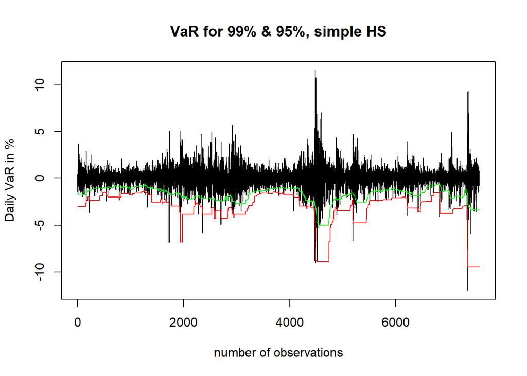

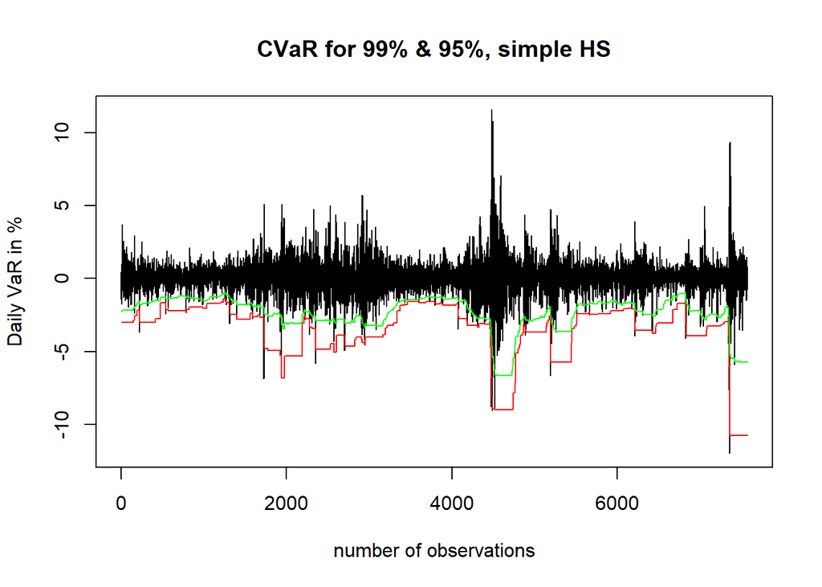

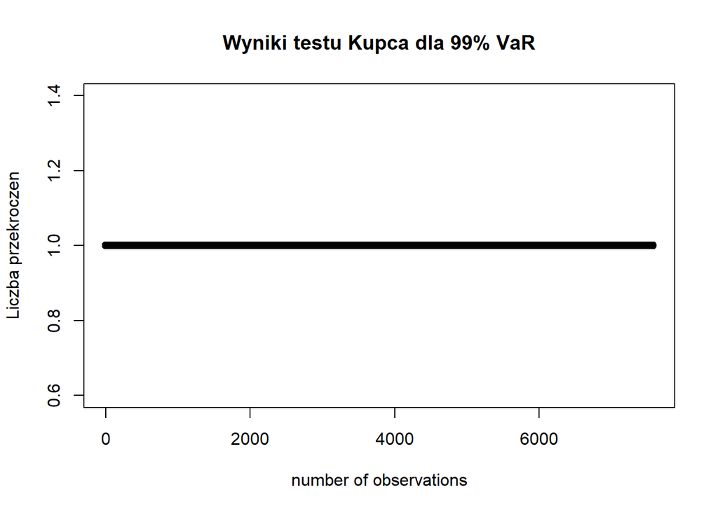

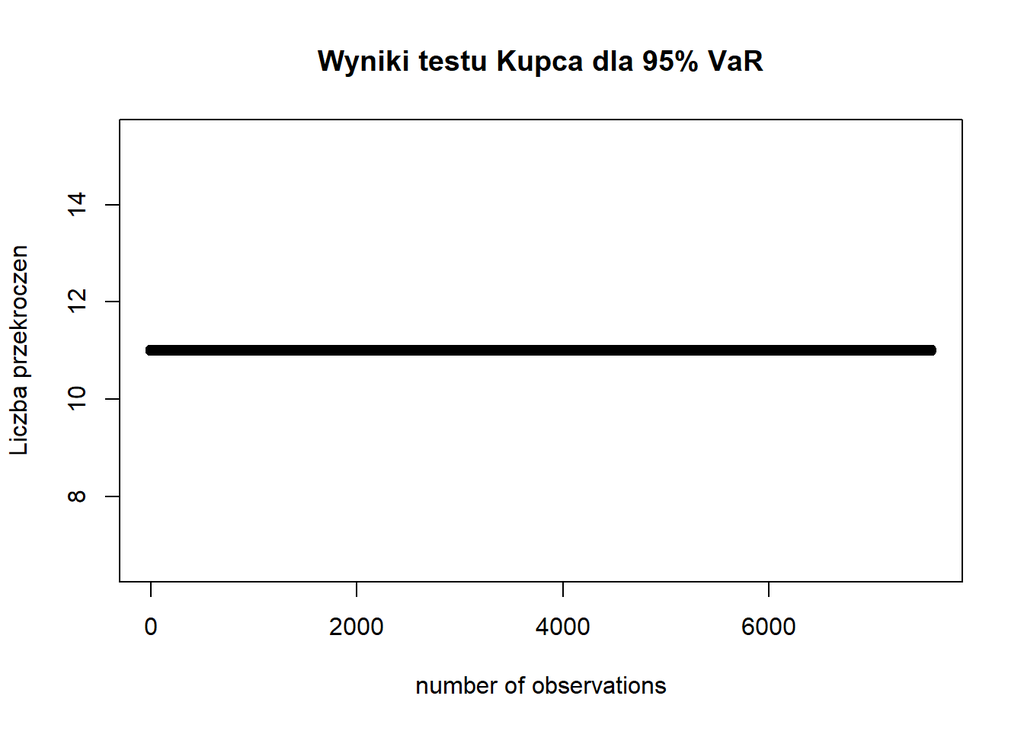

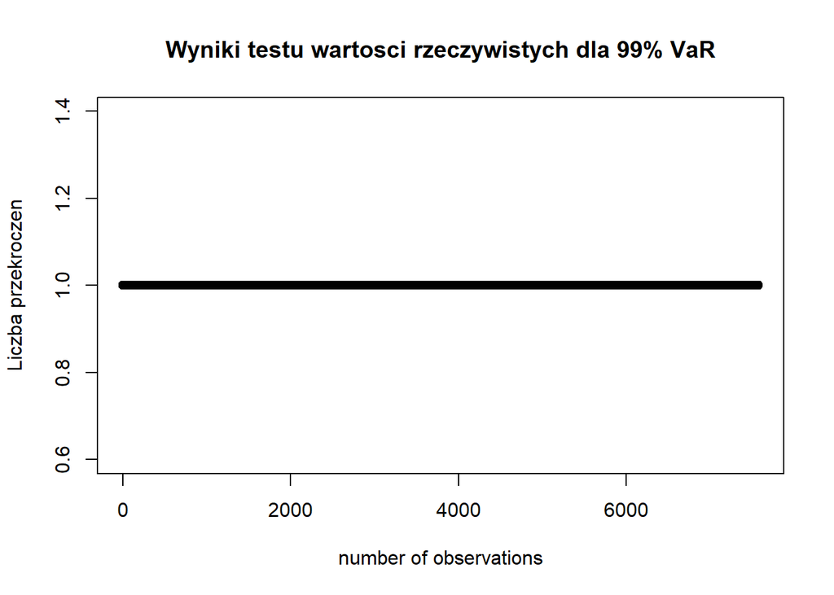

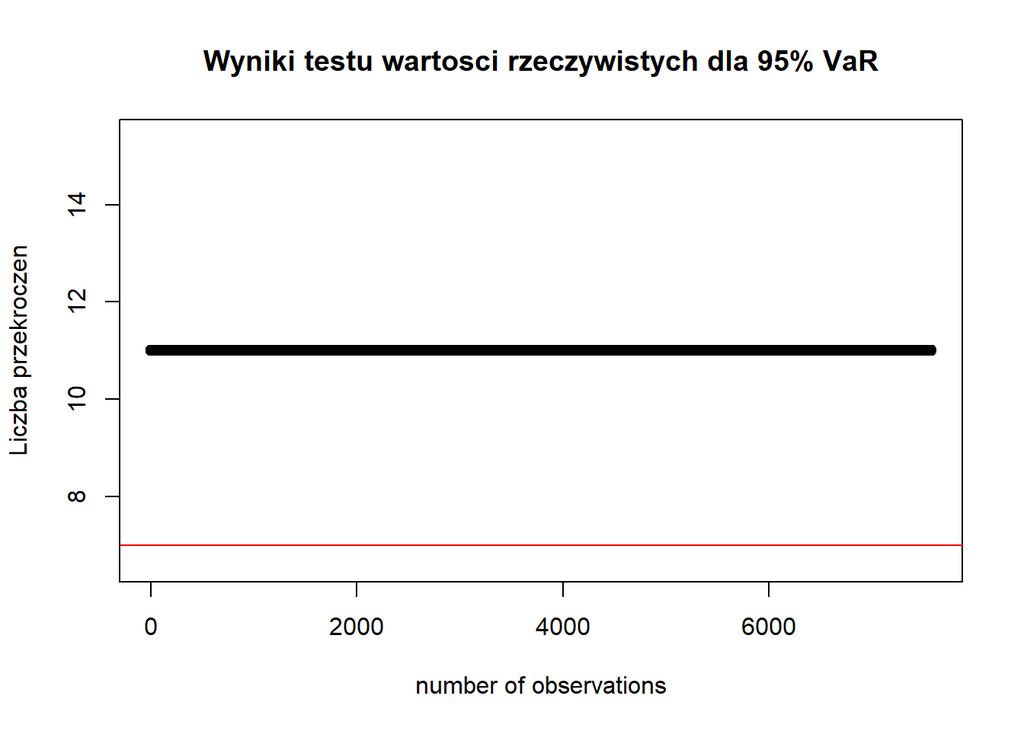

Na wykresach wyzej widzimy VaR 99% oraz VaR 95%. Na czarno jest pokazana funkcja zmiennosci. Widzimy, ze test Kupca oraz wartosci rzeczywistych nie ma zadnego sensu, przez konstrukcje metody historycznej prostej, co odzwierciedlaja wykresy.  
Dla testu Kupca oraz wartosci rzeczywistych przedzialy byly brane z wykladu. Dla testu Kupca, VaR 99% -> [0,7], VaR 95% -> [6,20]. Czerwone linie na wykresach sa dla w.w. przedzialow. Dla testu wartosci rzeczywistych, VaR 99% -> [0,5], VaR 95% -> [7,20].  
Popatrzmy teraz na wyniki **testu Christoffersona**.

```
## [1] "Liczba odrzucen H0 dla VaR 99%"
```

```
## [1] 0
```

```
## [1] "Liczba odrzucen H0 dla VaR 95%"
```

```
## [1] 2436
```

```
## [1] "Odsetek odrzuconych H0 do calosci dla VaR 95% w %"
```

```
## [1] 32.17116
```

Widzimy, ze wedlug testu **Christoffersona** dla VaR 99% liczba przekroczen wyniosla 0, natomiast dla VaR 95% liczba przekroczen wyniosla 32% od calosci, co jest sporym wynikiem -> 32% przekroczen zaleznych w czasie.  
# **Metoda historyczna z wagami**

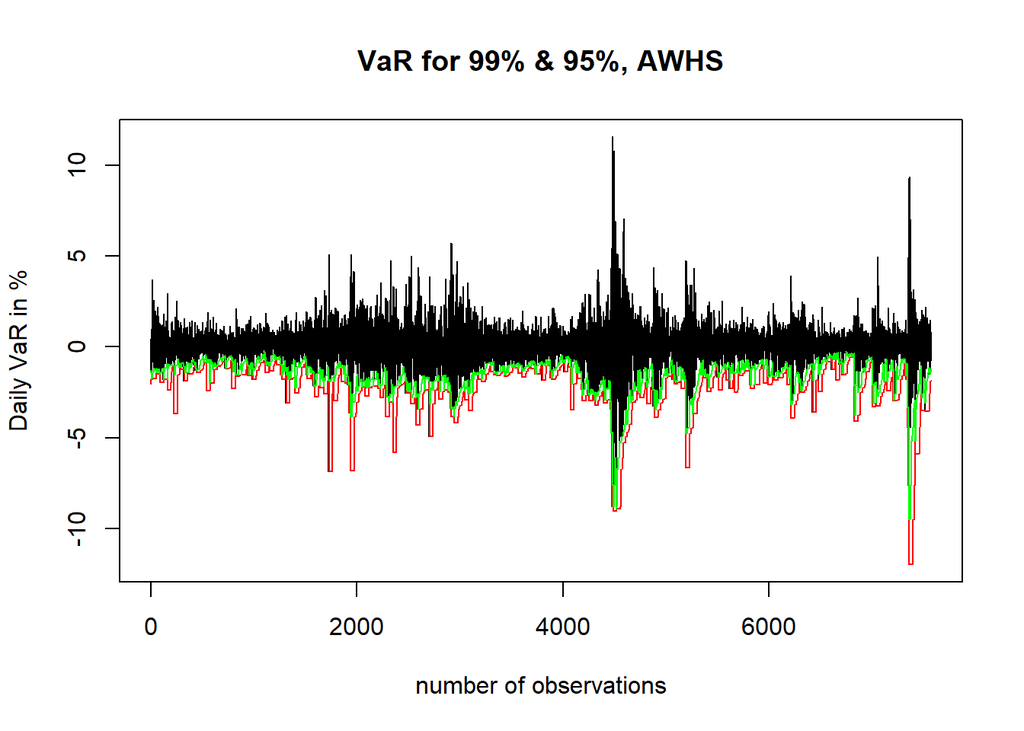

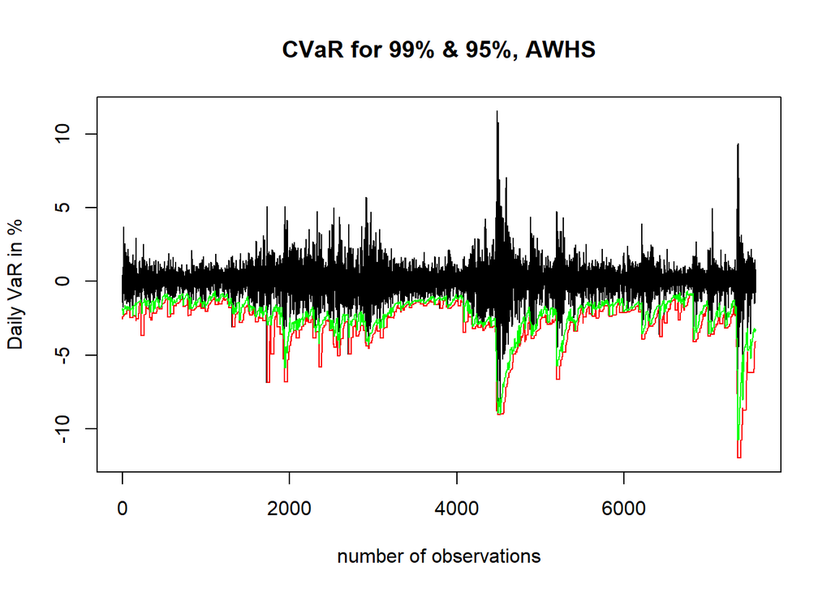

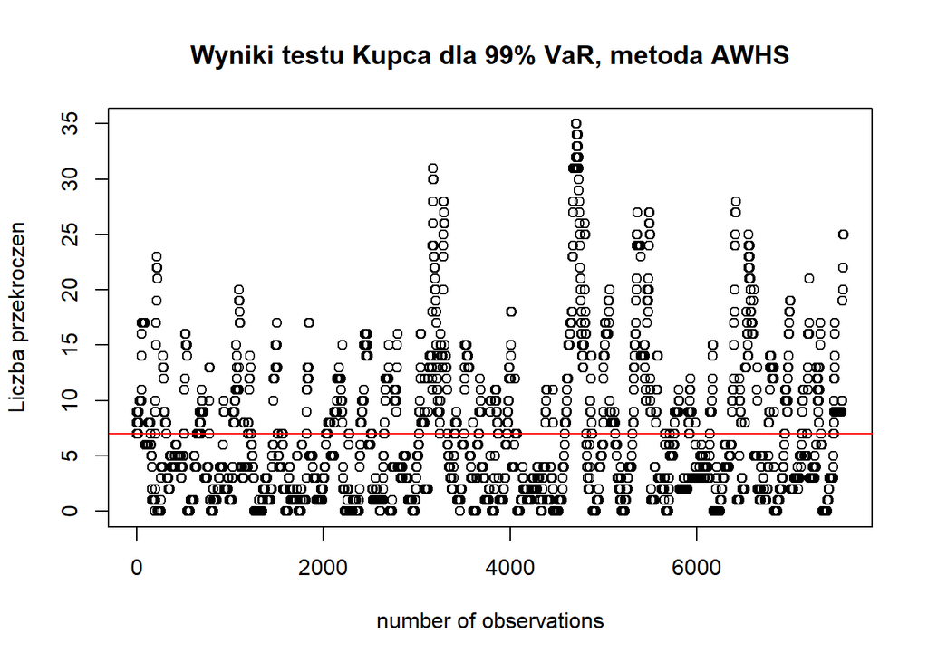

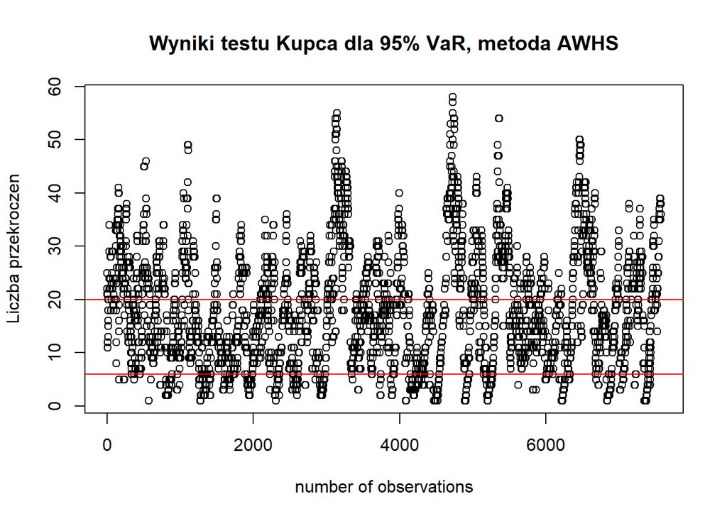

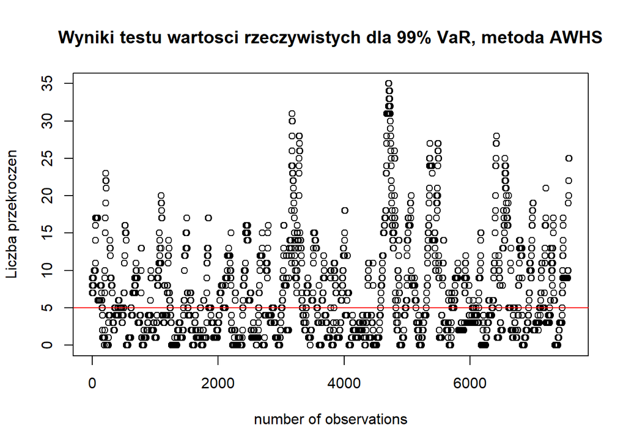

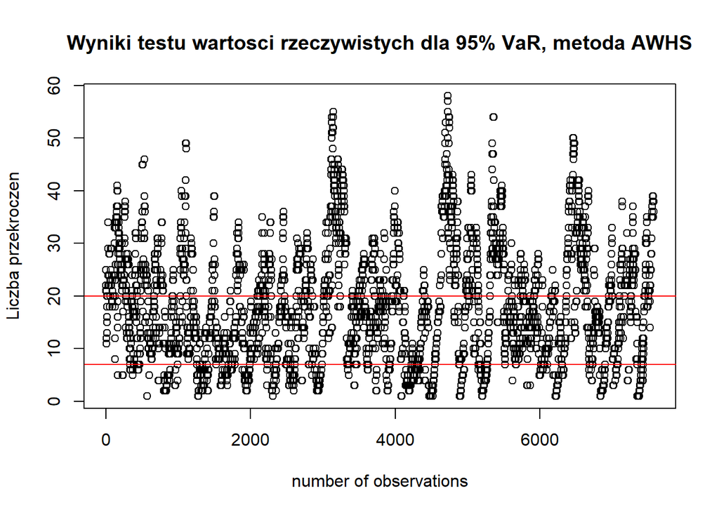

Na wykresach wyzej widzimy VaR 99% oraz VaR 95%. Na czarno jest pokazana funkcja zmiennosci.  
Na w.w. wykresach widzimy roznice pomiedzy metodami, metoda historyczna z wagami niweluje **“schodki”** widoczne na obu wykresach dla metody historycznej prostej.  
Rowniez latwo zauwazalne sa zmiany na wykresach dla testu Kupca oraz wartosci rzeczywistych.  
Nizej beda policzone liczby przekroczen dla w.w. testow oraz dla testu **Christoffersona**.

```
##                             99% VaR; 99 VaR w %; 95 VaR; 95% VaR w %
## test Christoffersona             956    12.62546    3462    45.72108
## test Kupca                      2425    32.02588    3732    49.28685
## test wartosci rzeczywistych     3008    39.72530    3988    52.66772
```

W tabeli wyzej widzimy liczbe przekroczen dla poszczegolnych testow, oraz udzial procentowy owych w calosci. Zwiekszenie VaRu -> zwieksza liczbe przekroczen, maksymalna jest rowna 53% zaleznych VaRow w czasie dla testu wartosci rzeczywistych.  
# **Metoda EWMA**

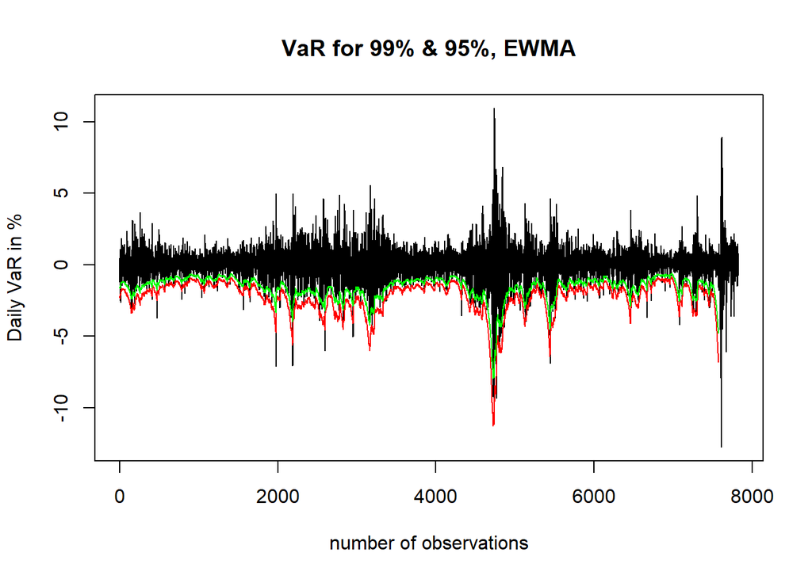

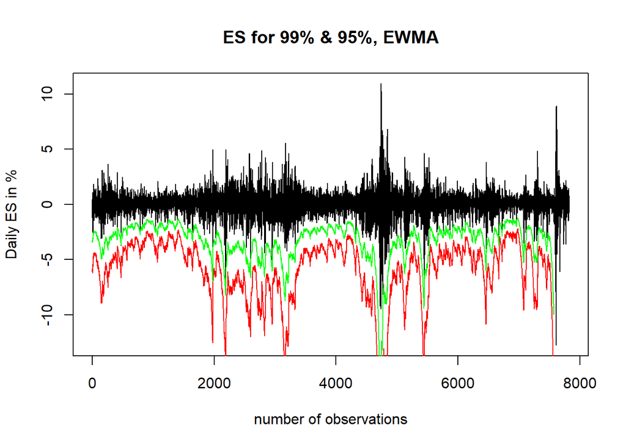

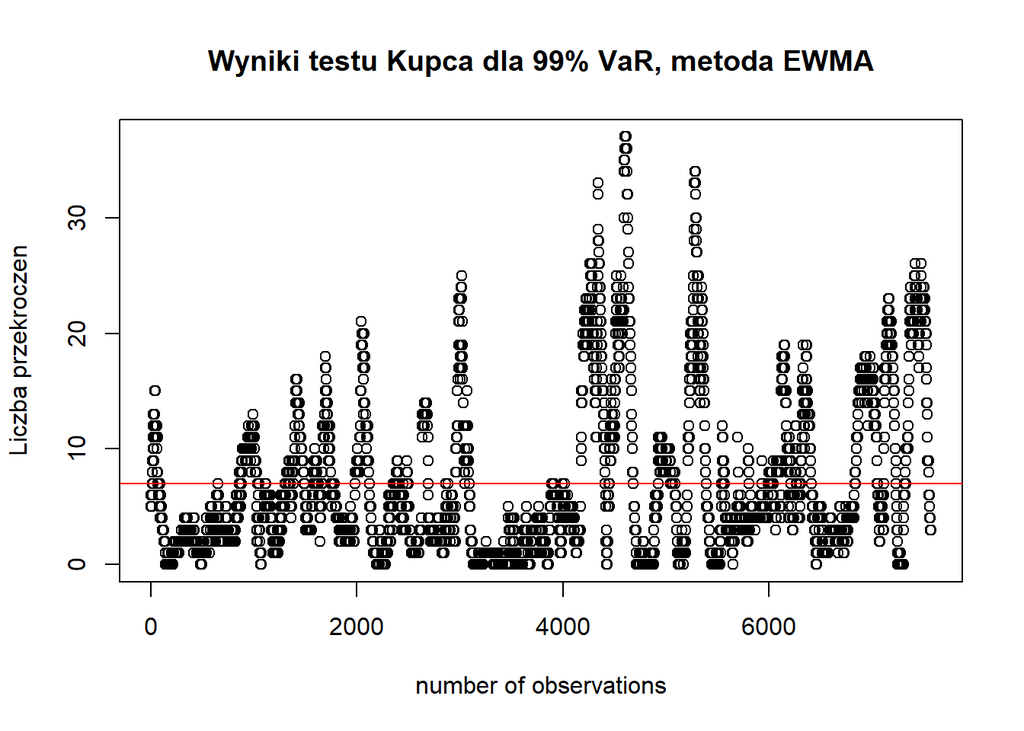

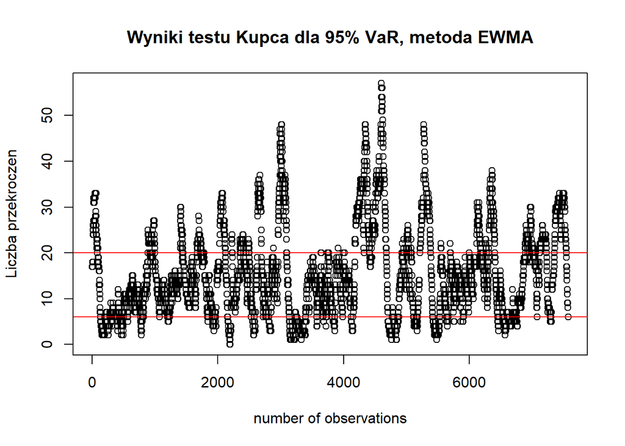

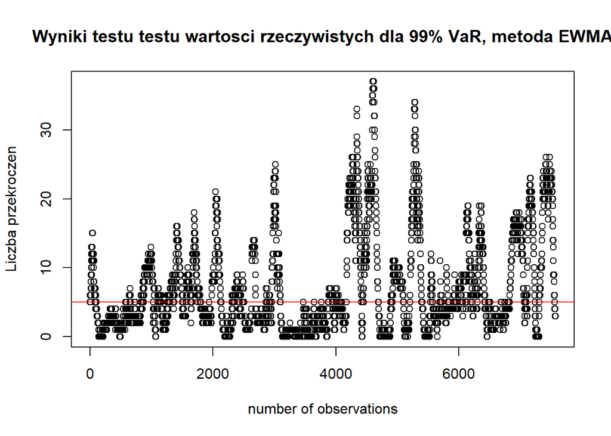

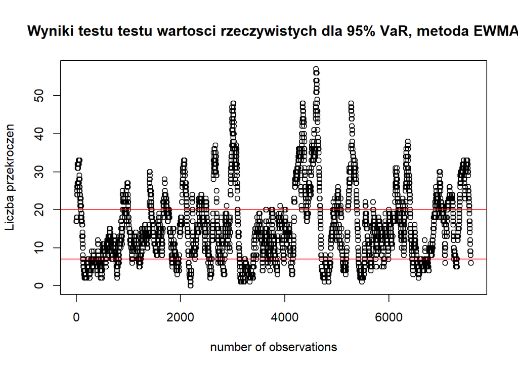

Dla metody **EWMA** byly wykorzystane stopy zwrotu logarytmiczne.  
Na wykresach wyzej widzimy VaR 99% oraz VaR 95%. Na czarno jest pokazana funkcja zmiennosci.  
Na w.w. wykresach latwo zauwazyc roznice pomiedzy wykresami dla wczesniej przedstawionych metod. Metoda **EWMA** bardziej **“nasladuje”** wykres zmiennosci. Rowniez widac roznice pomiedzy wykresami dla testu Kupca oraz wartosci rzeczywistych.  
Nizej beda policzone liczby przekroczen dla w.w. testow oraz dla testu **Christoffersona**.

```
##                             99% VaR; 99 VaR w %; 95 VaR; 95% VaR w %
## test Christoffersona            1276    16.85156    3319    43.83254
## test Kupca                      2443    32.26360    3047    40.24036
## test wartosci rzeczywistych     3138    41.44216    3415    45.10037
```

W tabeli wyzej widzimy, ze liczba przekroczen nadal rosnie w skutek zwiekszania VaRu, jednakze metoda **EWMA** pokazuje lepszy wynik niz **metdoa historyczna z wagami** dla VaRu 95%. Nadal widzimy, ze okolo polowy policzonych VaRow sa zalezne w czasie.  
# **PODSUMOWANIE**  
Najlepszy wynik dla VaR 95% zostal osiagniety metoda **historyczna prosta** i wyniosl okolo 32% zaleznych VaRow w czasie, jednakze metoda historyczna prosta jest dosc slabo skonstruowana dla pelnienia statystycznego podloza analizy koncowej. Dla VaR 95% lepiej sie spisala metoda **EWMA**, procentaz wartosci zaleznych w czasie wedlug kazdego z testow jest najmniejszy w przypadku owej metody. Dla VaR 99% delikatnie lepsza okazala sie metod **historyczna z wagami**. **Hipoteza badawcza** zostaje oddalona -> wyniki poszczegolnych metod roznia sie istotnie.  
# **DZIEKUJE ZA UWAGE**